# AI-assisted programming in biology

## AI-assisted programming in biology

### *Why learn to programme when AI can write code for you?*

An assistant can help you read a file, make sense of an error or get a first plot on the screen.

Say your plot shows how many animals you saw at two field sites. The count is higher at the site where you spent twice as long watching. **How would you *plot* the data to compare the sites fairly?**

Before asking for a plot, decide what a fair comparison would mean.

## Pollinator watches at Meadow

| Watch | Minutes | Pollinator visits |
| --- | --- | --- |
| Meadow, morning | 5 | 0 |
| Meadow, afternoon | 10 | 3 |
| Meadow, cancelled | 10 planned |  |

We want to report visits per minute. How many visits did we see in total, and how many minutes did we actually spend watching?

A watch can tell you something even when you see zero visits.

# Remember

Recall what each value in the table represents before you give it to a program.

## What does a language model generate?

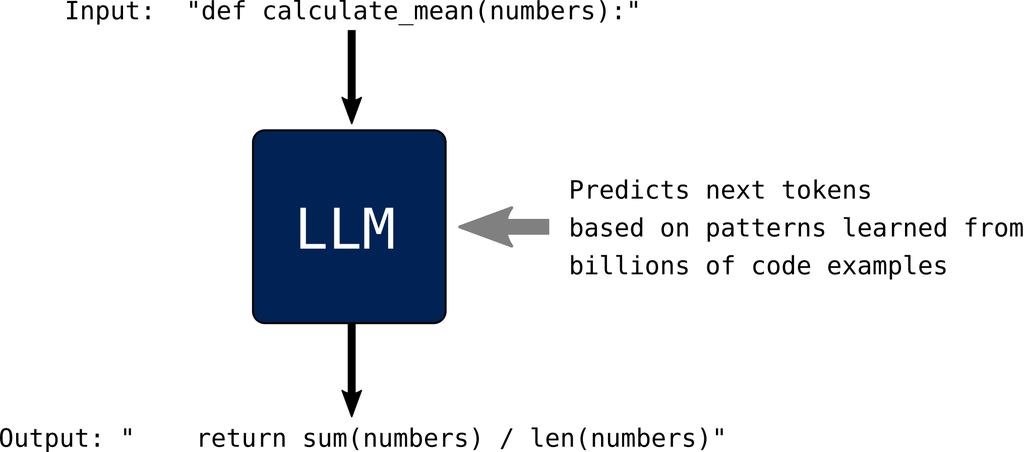

A **large language model (LLM)** learns patterns from text, often including code. Here it takes the first line of a Python function and suggests how to finish it.

The line looks familiar. What happens if you give it an empty list?

## One token at a time

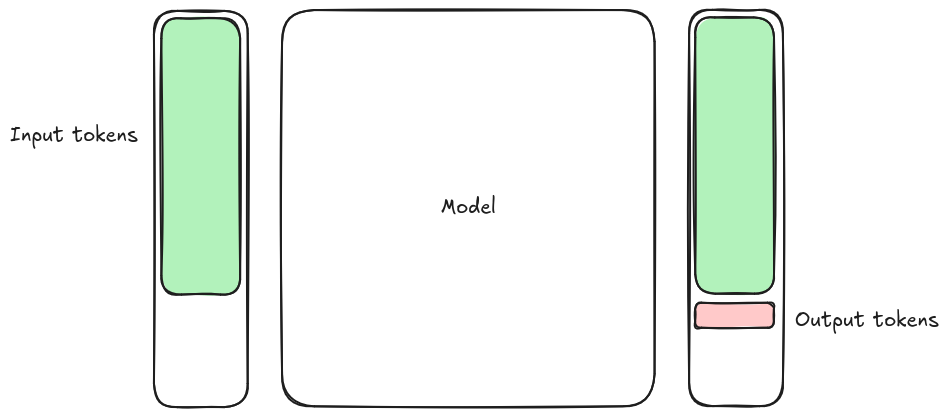

A **token** is a small piece of text. It might be a word, part of a word or a bracket.

Each new piece of text helps shape what the model writes next.

# Understand

Work out why two assistants might give different answers to the same question.

## How are code models trained?

**Pre-training.** The model learns patterns from many examples of text and code. It might learn what usually follows the first line of a Python function.

**Instruction tuning.** It sees examples of requests and useful replies, such as how to respond when someone asks, “What does this loop count?”

Examples can teach a model how to write and explain code. Tell it what the numbers in your own table represent.

## Cut-offs and context

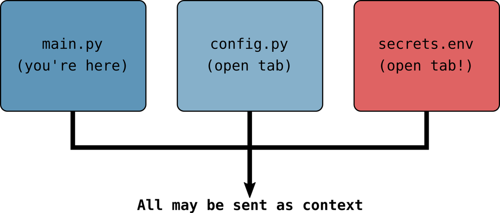

The model learned from examples collected up to a **cut-off date**. The information it receives for this reply is its **context**. The diagram shows how other open files might be included.

A **library** is a collection of code you can reuse. The Python library pandas gives you functions for working with tables.

If an assistant suggests a pandas function that’s changed, where would you check what it does in the version you’re using?

## Scenario I · Chat

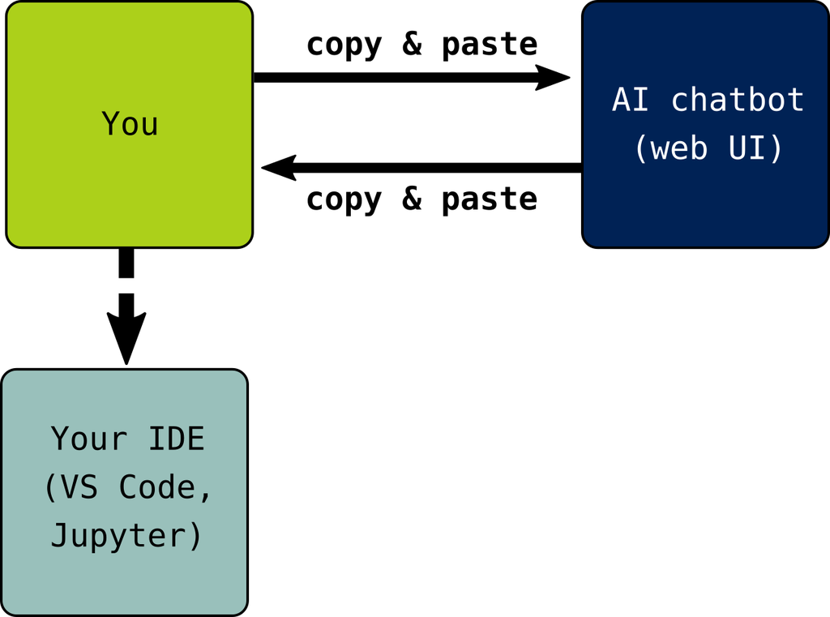

Type a question and decide what to try from the reply. What would you tell the assistant about the cancelled watch?

**Understand → Apply.** Explain why two replies disagree, then try a hint on a case you’ve worked out yourself.

## Scenario II · Editor assistance

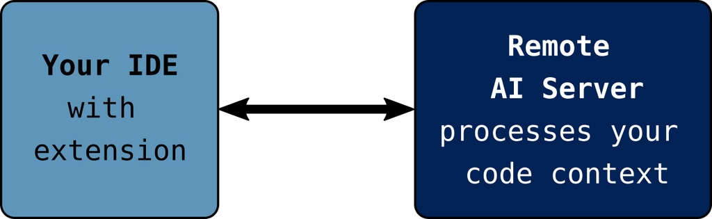

In this example, a remote service receives code context from your editor. When the suggestion appears right where you’re typing, it’s called an **inline completion**.

**Apply → Evaluate.** Read the suggested line in place. Predict what it will do, then try your check before deciding whether to keep it.

## Scenario III · Agents

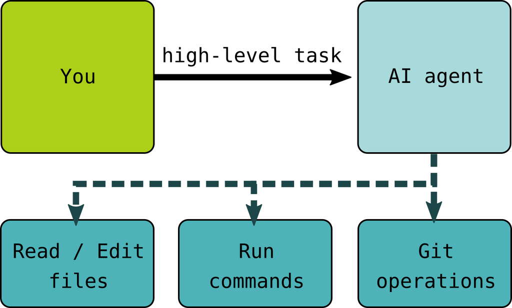

An **agent** can use tools to open files, edit code and run commands. You give it a task and decide what it may do.

**Analyse → Evaluate.** Read the plan, then check which files changed and what commands ran.

# Apply

Try a suggestion on a case you can work out by hand.

## Check a suggestion before you keep it

1. You watched for five minutes and saw zero visits.
2. You cancelled the watch before it began.

What should the program report for each case?

Write down both answers first. Then try the same two cases on the suggested code.

Apply exercise

# Analyse

Follow the values through the code until you see where the answer changes.

## Where did the extra minutes come from?

Keep a running total of the visits and the time spent watching. Here’s the first row worked out.

| After reading this row | Visits so far | Minutes watched so far |
| --- | --- | --- |
| Morning | 0 | 5 |
| Afternoon | ? | ? |
| Cancelled | ? | ? |

If the time goes up when you read the cancelled row, look for the line that added those minutes.

## Agent demonstration · one report change

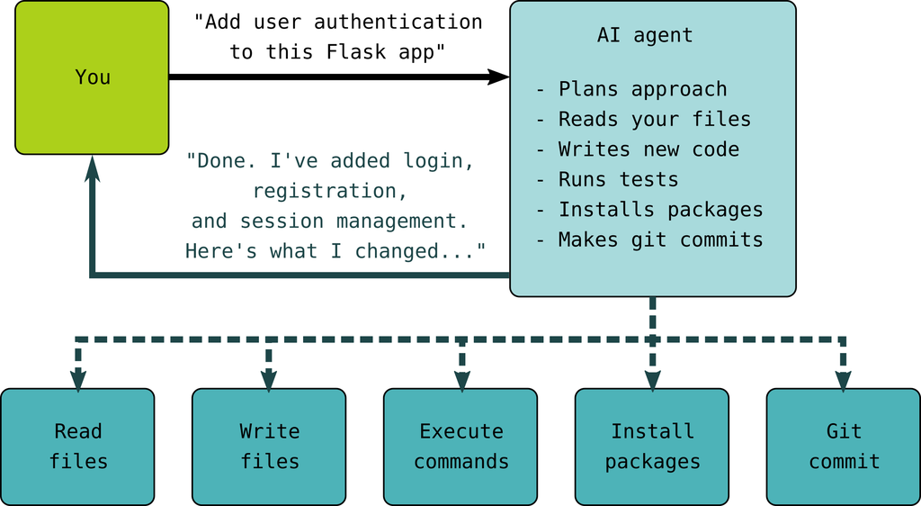

The diagram shows several actions an agent might take on a larger task. For our survey, ask for one report column. A **diff** shows which lines changed.

Read the diff. Then check that the new column gives you the minutes you expected and that the visit rate still agrees with your hand calculation.

## AI-assisted version control

```
-    writer.writerow(["site", "visits_per_minute"])
+    writer.writerow(["site", "observed_minutes", "visits_per_minute"])
```

A minus marks the old line and a plus marks its replacement. This part of the change adds a column heading.

What would you check before trusting an AI summary of this change?

Read the whole diff. Then use Git to **stage** the changes you want to save together.

Optional practical

# Evaluate

Decide what you’d keep and explain which check helped you decide.

## Three questions about the same change

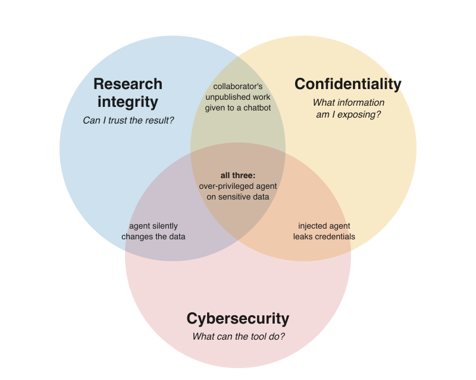

**Does the number make sense?** Check how the rate was calculated.

**May I send this file?** Think about who is allowed to see it.

**What can the tool do?** Check what it can read, change or run.

These questions can come up together. An agent might open an unpublished survey and then alter the data used to produce a result.

## Make a decision someone else can check

Say you expect three visits in 15 minutes. The script runs, but divides by 25 minutes after adding the cancelled watch.

What would you change? What would you tell someone who had already used that rate to compare sites?

Write down the case you checked, the result you got and what you decided to keep or change.

Evaluate exercise

# Create

Decide what you want to learn from the data before asking for code.

## Which comparison are you trying to make?

**Use all the time you watched.** Add the visits at a site and divide by the total time you actually spent watching.

**Give each completed watch equal weight.** Work out a rate for each watch, then average those rates.

Choose a comparison you can explain. Find two watches for which these calculations would give different answers.

## Try this independently

Open the final exercise. It gives you a new set of watches and a suggested change.

1. Work out what you expect, then write and run your own check.
2. Decide whether to keep the change and tell us why.
3. Say what the result tells you about the sites you watched.

Your explanation should make sense to someone who has only the data, the code and your check.

## Sources and figure credits

Adapted from CodeRefinery, Enrico Glerean, Bjørn Lindi, Ina Pöhner, Jarno Rantaharju, Simon Christ, Thomas Pfau, Bahareh Tasdighi and Ashwin Mohanan, *Responsible Use of Generative AI in Assisted Coding*, 2026-11-13. [DOI 10.5281/zenodo.19335927](https://doi.org/10.5281/zenodo.19335927) · [Pinned source](https://github.com/coderefinery/coding-with-ai/tree/d1a0a7049d890f5ebeb9ee6ee713a40d810a2572)

Copyright (c) CodeRefinery. MQB reorganised the lesson around Bloom, developed the pollinator practical and checks for the workshop. Adapted instructional material is [CC BY 4.0](https://creativecommons.org/licenses/by/4.0/). The original MQB scripts and synthetic data carry the [MQB MIT licence](https://github.com/MulQuaBio/MQB/blob/main/LICENSE).

The six categories follow [Krathwohl (2002)](https://doi.org/10.1207/s15430421tip4104_2). The MQB Collective developed their application to quantitative biology. The token diagram is credited to Simo Tuomisto.

Use the chapter to try the exercises. The worksheet helps you work through them in two hours.

Full chapter and figure credits · Workshop worksheet · Copilot setup